# Changing established atttiudes via the IAT: Experiment 1

Ian Hussey

```r
knitr::opts_chunk$set(message=FALSE,
                      warning=FALSE,
                      cache.lazy=FALSE)
```

```r
# dependencies
library(tidyverse)
library(psych)
library(weights)  # for rd(), a round() alternative
library(plotrix)  # for std.error
library(lme4)
library(effects)
library(knitr)
library(kableExtra)
library(sjPlot)
library(apa)

# rounds all numerics in a df
round_df <- function(df, digits) {
  nums <- vapply(df, is.numeric, FUN.VALUE = logical(1))
  df[,nums] <- round(df[,nums], digits = digits)
  (df)
}

# options
options(knitr.table.format = "html") # necessary configuration of tables

# disable scientific notation
options(scipen = 999)
```

# Descriptive statistics

## Full sample

Assess selective attrition between conditions.

```r
# get data
data_df <-
  read.csv("data/processed/processed summary data - wide format.csv") %>%
  dplyr::mutate(gender = as.factor(gender))

#colnames(data_df)

attrition_rate <- data_df %>%
  dplyr::summarize(rate = round(sum(exclude)/n()*100, 1)) %>%
  as.numeric()

data_df %>%
  count(exclude) %>%
  kable() %>%
  kable_styling(bootstrap_options = c("striped", "hover", "condensed"), full_width = FALSE)
```

| exclude | n |
| --- | --- |
| FALSE | 148 |
| TRUE | 11 |

```r
chi2_result <- data_df %>%
  count(IAT_condition, exclude) %>%
  spread(exclude, n) %>%
  select(-IAT_condition) %>%
  chisq.test(.) %>%
  chisq_apa(., print_n = TRUE, format = c("rmarkdown"), info = FALSE, print = FALSE)
```

Attrition rate = 6.9%.

A chi squared test was used to assess whether the conditions suffered from differential attrition rates: $\chi^2$(1, n = 159) = 0.00, *p* = .000. [nb results of p = 1.0 will show as = .000 due to an error in how chisq_apa trims its results]

## Analytic sample

I.e., after applying inclusion/exclusion criteria.

### Age

```r
passers_df <- data_df %>%
  filter(exclude == FALSE)

passers_df %>%
  dplyr::select(age) %>%
  psych::describe(fast = TRUE,  # subset of descriptive stats
                  ranges = FALSE,
                  trim = 0) %>%
  dplyr::select(-vars, -se) %>%
  kable() %>%
  kable_styling(bootstrap_options = c("striped", "hover", "condensed"), full_width = FALSE)
```

|  | n | mean | sd |
| --- | --- | --- | --- |
| age | 148 | 32.10135 | 11.09436 |

### Gender

```r
passers_df %>%
  dplyr::count(gender) %>%
  kable() %>%
  kable_styling(bootstrap_options = c("striped", "hover", "condensed"), full_width = FALSE)
```

| gender | n |
| --- | --- |
| 24 | 1 |
| 33 | 1 |
| female | 46 |
| feminine | 1 |
| male | 98 |
| nonbinary | 1 |

### Performance on the IAT and SC-IAT

```r
passers_df %>%
  dplyr::select(IAT_mean_RT,
                IAT_perc_acc,
                SCIAT_mean_RT,
                SCIAT_perc_acc) %>%
  psych::describe(fast = TRUE,  # subset of descriptive stats
                  ranges = FALSE,
                  trim = 0) %>%
  dplyr::select(-vars, -se) %>%
  dplyr::mutate(mean = round(mean, 2),
         sd = round(sd, 2)) %>%
  kable() %>%
  kable_styling(bootstrap_options = c("striped", "hover", "condensed"), full_width = FALSE)
```

| n | mean | sd |
| --- | --- | --- |
| 148 | 831.63 | 194.55 |
| 148 | 0.93 | 0.07 |
| 148 | 687.65 | 143.77 |
| 148 | 0.92 | 0.07 |

# Hypothesis test 1: Differences in IAT effects between contrast pair conditions

H1: Completing an IAT serves to train attitudes as well as test them. Participants who complete a race IAT will demonstrate more negative implicit evaluations of the outgroup (black people) on the SCIAT than participants who completed a control (flowers-insects) IAT.

## Outlier removal

Exclude data points > 2.5 SD from mean.

```r
# exclude participants who had more than 10% of trials in less than 300ms, and make variables factors
SCIAT_data <-
  read.csv("data/processed/processed SCIAT data - long format.csv") %>%
  dplyr::mutate(participant = as.factor(participant),
         block = as.factor(ifelse(block == "compatible", "black-positive",
                        ifelse(block == "incompatible", "black-negative", NA))),
         IAT_condition = as.factor(IAT_condition)) %>%
  dplyr::rename(SCIAT_block = block) %>%
  filter(IAT_exclude_based_on_fast_trials == FALSE &
           SCIAT_exclude_based_on_fast_trials == FALSE)

# exclude outlier rts
SCIAT_data_outliers_removed <-
  SCIAT_data %>%
  schoRsch::outlier(dv = "rt",
                    todo = "elim",
                    upper.z = 2.5,
                    lower.z = -2.5)
```

```
## [1] "Function outlier() has screened 20300 trial(s) in total. Of these were 112 trial(s) identified as outliers (0.55%)."
```

```r
# Check that variables that should be factors are indeed factors
sapply(SCIAT_data_outliers_removed, class)
```

```
##                        participant                        SCIAT_block
##                           "factor"                           "factor"
##                            trial_n                                 rt
##                          "integer"                          "integer"
##                           accuracy                      IAT_condition
##                          "integer"                           "factor"
##                        block_order                         task_order
##                           "factor"                           "factor"
##                             gender                                age
##                           "factor"                          "integer"
##          modern_racism_scale_total   IAT_exclude_based_on_fast_trials
##                          "integer"                          "logical"
## SCIAT_exclude_based_on_fast_trials                            exclude
##                          "logical"                          "logical"
##                            outlier                            zscores
##                          "numeric"                          "numeric"
```

### Plot distribution

Distribution of SC-IAT RTs after trimming outliers.

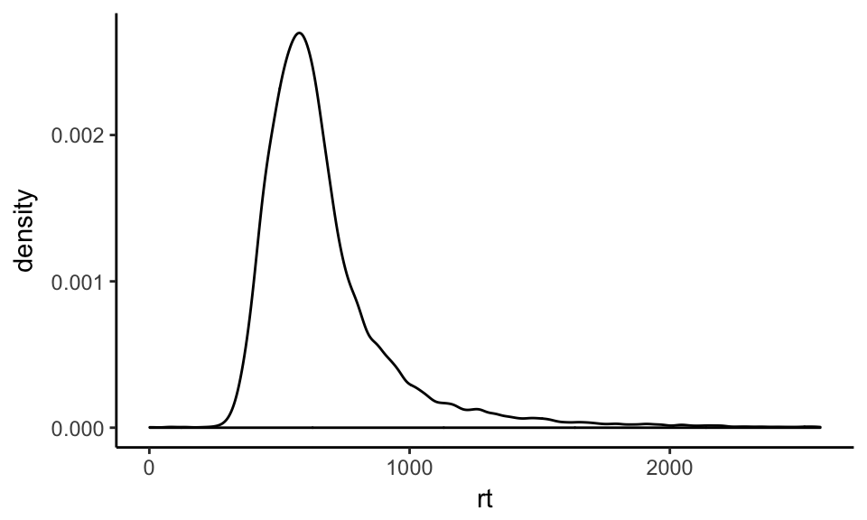

```r
ggplot(data = SCIAT_data_outliers_removed) +
  geom_density(aes(x = rt)) +
  theme_classic()
```

## Linear mixed model

### Model

```r
model_1 <- lmer(rt ~ SCIAT_block * IAT_condition + modern_racism_scale_total + (1 | participant),
                contrasts = list(SCIAT_block = "contr.sum", IAT_condition = "contr.sum"),
                data = SCIAT_data_outliers_removed)
```

- Hypothesis refers to the IAT_condition*SCIAT_block interaction effect.
- Confidence intervals via Wald estimation.

### Summary

```r
sjt.lmer(model_1,
         emph.p = FALSE,
         p.kr = FALSE,
         show.std = TRUE,
         digits.est = 3,
         digits.ci = 3)
```

|  |  | B | CI | std. Beta | CI | p |
| --- | --- | --- | --- | --- | --- | --- |
| Fixed Parts |  |  |  |  |  |  |
| (Intercept) |  | 662.789 | 601.301 – 724.277 |  |  | <.001 |
| SCIAT_block1 |  | -0.992 | -4.421 – 2.437 | -0.004 | -0.017 – 0.009 | .571 |
| IAT_condition1 |  | -7.595 | -24.300 – 9.109 | -0.028 | -0.091 – 0.034 | .373 |
| modern_racism_scale_total |  | 0.716 | -2.565 – 3.997 | 0.014 | -0.049 – 0.076 | .669 |
| SCIAT_block1:IAT_condition1 |  | 4.459 | 1.030 – 7.887 | 0.017 | 0.004 – 0.029 | .011 |
| Random Parts |  |  |  |  |  |  |
| σ<sup>2</sup> |  | 61756.321 |  |  |  |  |
| τ<sub>00, participant</sub> |  | 10073.147 |  |  |  |  |
| N<sub>participant</sub> |  | 145 |  |  |  |  |
| ICC<sub>participant</sub> |  | 0.140 |  |  |  |  |
| Observations |  | 20188 |  |  |  |  |
| R<sup>2</sup> / Ω<sub>0</sub><sup>2</sup> |  | .143 / .143 |  |  |  |  |

### Plot effects

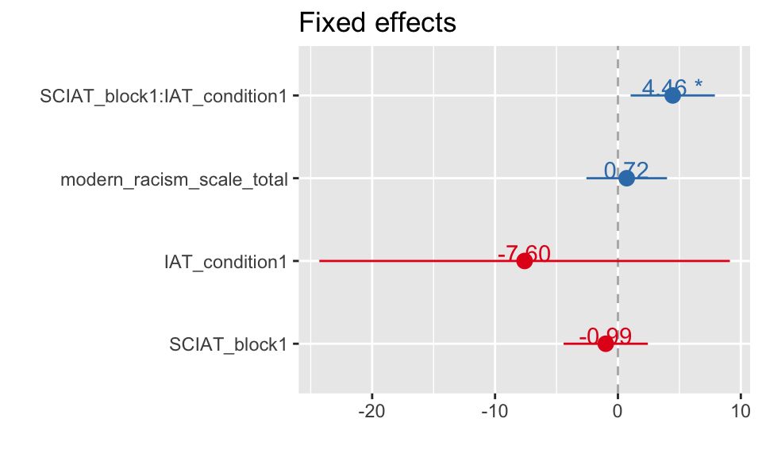

```r
sjp.lmer(model_1,
         p.kr = FALSE,
         type = "fe")
```

### Table predictions

```r
model_1_predicted_effects <-
  as.data.frame(effect("SCIAT_block:IAT_condition", model_1)) %>%
  dplyr::rename(`IAT condition` = IAT_condition,
         `SCIAT block` = SCIAT_block)

model_1_predicted_effects %>%
  round_df(2) %>%
  kable() %>%
  kable_styling(bootstrap_options = c("striped", "hover", "condensed"), full_width = FALSE)
```

| SCIAT block | IAT condition | fit | se | lower | upper |
| --- | --- | --- | --- | --- | --- |
| black-negative | Flowers-Insects IAT | 671.58 | 12.17 | 647.72 | 695.44 |
| black-positive | Flowers-Insects IAT | 664.64 | 12.17 | 640.78 | 688.51 |
| black-negative | Race IAT | 677.85 | 12.43 | 653.49 | 702.21 |
| black-positive | Race IAT | 688.75 | 12.43 | 664.39 | 713.11 |

### Plot predictions

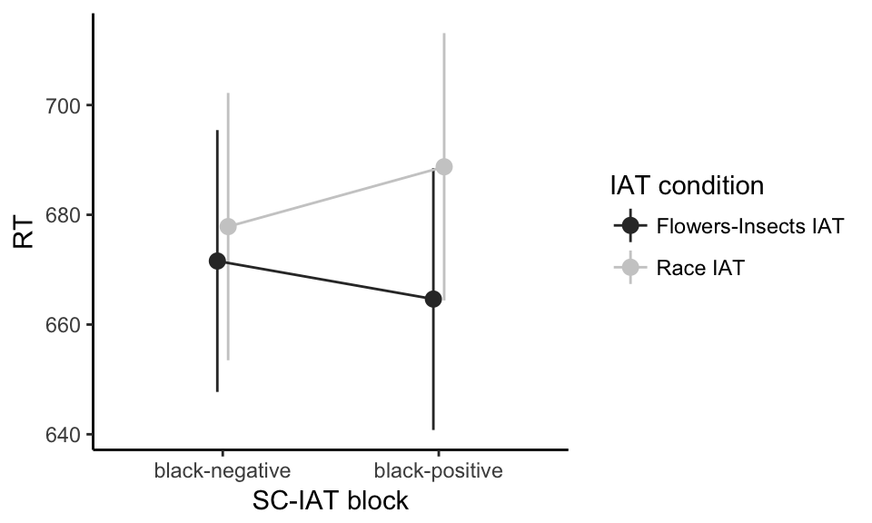

```r
ggplot(data = model_1_predicted_effects,
       aes(x = `SCIAT block`, y = fit, colour = `IAT condition`)) +
  geom_pointrange(aes(ymax = upper,
                      ymin = lower),
                  position = position_dodge(width = .1)) +
  geom_line(aes(group = `IAT condition`),
            position = position_dodge(width = .1)) +
  ylab("RT") +
  xlab("SC-IAT block") +
  scale_colour_grey() +
  theme_classic()
```

```r
  # theme(legend.justification=c(0.5,1), legend.position=c(0.5,1),
  #       legend.key = element_rect(colour = "transparent"))
```

## Alternative analytic strategy: Linear fixed effect model on SC-IAT D1 scores

For illustrative/reader familiarity purposes only.

### Model

```r
model_1_alt <- lm(SCIAT_D1 ~ IAT_condition + modern_racism_scale_total,
                  contrasts = list(IAT_condition = "contr.sum"),
                  data = passers_df)
```

### Summary

```r
sjt.lm(model_1_alt,
       emph.p = FALSE,
       show.std = TRUE)
```

|  |  | B | CI | std. Beta | CI | p |
| --- | --- | --- | --- | --- | --- | --- |
| (Intercept) |  | 0.25 | 0.05 – 0.44 |  |  | .014 |
| IAT_condition (Race IAT) |  | 0.03 | -0.02 – 0.08 | 0.09 | -0.07 – 0.25 | .277 |
| modern_racism_scale_total |  | -0.01 | -0.02 – -0.00 | -0.20 | -0.36 – -0.04 | .013 |
| Observations |  | 148 |  |  |  |  |
| R<sup>2</sup> / adj. R<sup>2</sup> |  | .048 / .035 |  |  |  |  |

### Plot effects

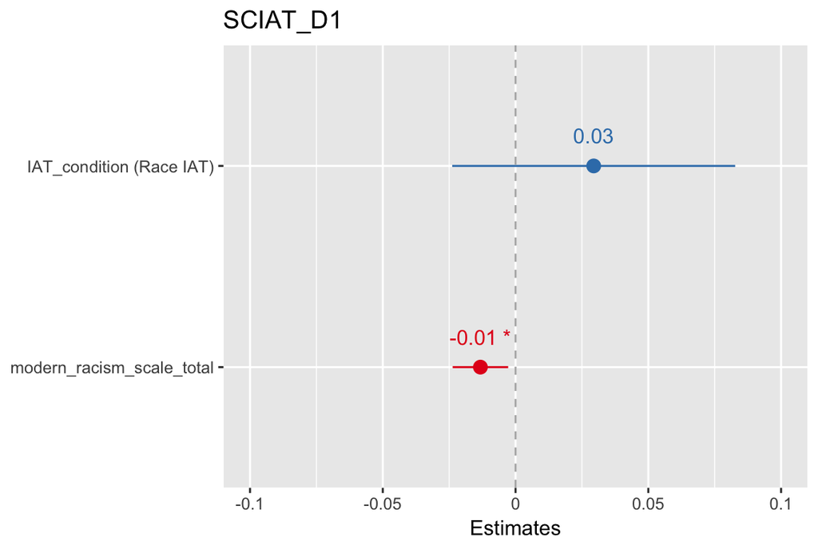

```r
sjp.lm(model_1_alt,
       type = "fe")
```

### Estimate effect size

Differences between groups are more meaningful when experessed as Cohen’s d, so regress against racism (the covariate) and then compare group differences in the residuals.

```r
model_1a_alt <- lm(SCIAT_D1 ~ modern_racism_scale_total,
                   data = passers_df)

temp <- passers_df %>%
  rownames_to_column()

resid_data <- residuals(model_1a_alt) %>%
    as.data.frame()
colnames(resid_data) <- "residual_SCIAT_D1"
resid_data <- resid_data %>%
  rownames_to_column() %>%
  left_join(temp, by = "rowname")

effsize::cohen.d(residual_SCIAT_D1 ~ IAT_condition, data = resid_data)
```

```
##
## Cohen's d
##
## d estimate: 0.1800852 (negligible)
## 95 percent confidence interval:
##        inf        sup
## -0.1455116  0.5056819
```

# Hypothesis test 2: Differences in self-reported ratings between contrast pair conditions

H2: Completing an IAT serves to train attitudes as well as test them. Participants who complete a race IAT will demonstrate more negative self-reported evaluations of the outgroup (black people) on the ratings than participants who completed a control (flowers-insects) IAT.

```r
ratings_data <-
  read.csv("data/processed/processed ratings data - long format.csv") %>%
  dplyr::mutate(participant = as.factor(participant)) %>%
  mutate(IAT_condition = fct_relevel(as.factor(IAT_condition), "Race IAT", "Flowers-Insects IAT")) %>%
  filter(IAT_exclude_based_on_fast_trials == FALSE &
           SCIAT_exclude_based_on_fast_trials == FALSE)
```

## Linear mixed model

### Model

```r
model_2 <- lmer(rating ~ IAT_condition + modern_racism_scale_total + (1 | participant),
                contrasts = list(IAT_condition = "contr.sum"),
                data = ratings_data)
```

### Summary

```r
sjt.lmer(model_2,
         emph.p = FALSE,
         p.kr = FALSE,
         show.std = TRUE)
```

|  |  | B | CI | std. Beta | CI | p |
| --- | --- | --- | --- | --- | --- | --- |
| Fixed Parts |  |  |  |  |  |  |
| (Intercept) |  | 5.77 | 5.26 – 6.28 |  |  | <.001 |
| IAT_condition (Flowers-Insects IAT) |  | -0.04 | -0.18 – 0.10 | -0.04 | -0.17 – 0.09 | .560 |
| modern_racism_scale_total |  | -0.08 | -0.11 – -0.06 | -0.40 | -0.52 – -0.27 | <.001 |
| Random Parts |  |  |  |  |  |  |
| σ<sup>2</sup> |  | 0.348 |  |  |  |  |
| τ<sub>00, participant</sub> |  | 0.667 |  |  |  |  |
| N<sub>participant</sub> |  | 145 |  |  |  |  |
| ICC<sub>participant</sub> |  | 0.657 |  |  |  |  |
| Observations |  | 870 |  |  |  |  |
| R<sup>2</sup> / Ω<sub>0</sub><sup>2</sup> |  | .755 / .752 |  |  |  |  |

### Plot effects

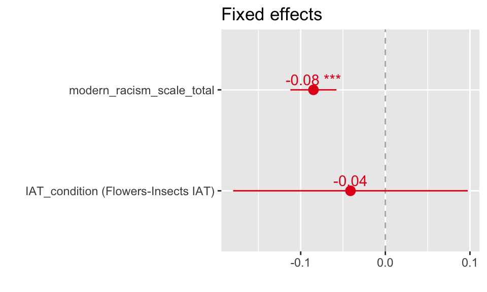

```r
sjp.lmer(model_2,
         p.kr = FALSE,
         type = "fe")
```

### Table predictions

```r
model_2_predicted_effects <- as.data.frame(effect("IAT_condition", model_2))

model_2_predicted_effects %>%
  round_df(2) %>%
  kable() %>%
  kable_styling(bootstrap_options = c("striped", "hover", "condensed"), full_width = FALSE)
```

| IAT_condition | fit | se | lower | upper |
| --- | --- | --- | --- | --- |
| Race IAT | 4.20 | 0.1 | 4.00 | 4.40 |
| Flowers-Insects IAT | 4.28 | 0.1 | 4.09 | 4.48 |

### Plot predictions

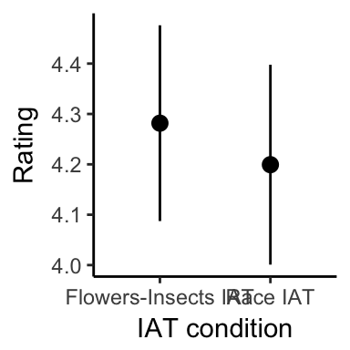

```r
ggplot(data = model_2_predicted_effects,
       aes(x = IAT_condition, y = fit)) +
  geom_pointrange(aes(ymax = upper,
                      ymin = lower)) +
  ylab("Rating") +
  xlab("IAT condition") +
  scale_colour_grey() +
  theme_classic()
```